# randomforest

2025-10-03

In this section of the project we examine technique uses to build a classifier model for detecting fradulent credit card transaction. The data used is provided by https://www.kaggle.com/datasets/mlg-ulb/creditcardfraud. It shows a dataset of credit card transaction occured in two days on September 2013 by European cardholders. This particular data has the benefit of having already gone through preprocessing and PCA has been done to it. Hence most of the preprosessing steps can be skip here. Therefore we can go right into the basic EDA

First we download the data

```r
pkgs <- c("curl","readr","tidyverse","dplyr","corrplot","randomForest", "caret", "smotefamily", "pROC")

for(p in pkgs){
    if (!require(p,character.only=TRUE)) install.packages(p)
}
```

```
## Using libcurl 8.14.1 with Schannel
```

```r
library(curl)
library(readr)
library(tidyverse)
library(dplyr)
library(corrplot)
library(randomForest)
library(caret)
library(smotefamily)
library(pROC)
zip_url  <- "https://github.com/railtonjamesl-collab/ds-project/raw/main/dataset/archive.zip"
zip_file <- tempfile(fileext = ".zip")

# 1) Download in binary mode
curl_download(zip_url, zip_file, mode = "wb")

# 2) List contents to see EXACT internal names
listing <- unzip(zip_file, list = TRUE)$Name
print(listing)  # <- check this output to know the exact path(s)
```

```
## [1] "creditcard.csv"
```

```r
# 3) Auto-pick a CSV inside (first match)
csvs <- listing[grepl("\\.csv$", listing, ignore.case = TRUE)]
stopifnot(length(csvs) > 0)  # fail early if no CSVs
csv_inside <- csvs[1]
message("Reading CSV inside zip: ", csv_inside)
```

```
## Reading CSV inside zip: creditcard.csv
```

```r
# 4) Read without extracting
df <- read_csv(unz(zip_file, csv_inside))
```

first we explore the surface behaviour of the data set

```r
summary(df)
```

```
##       Time              V1                  V2                  V3
##  Min.   :     0   Min.   :-56.40751   Min.   :-72.71573   Min.   :-48.3256
##  1st Qu.: 54202   1st Qu.: -0.92037   1st Qu.: -0.59855   1st Qu.: -0.8904
##  Median : 84692   Median :  0.01811   Median :  0.06549   Median :  0.1799
##  Mean   : 94814   Mean   :  0.00000   Mean   :  0.00000   Mean   :  0.0000
##  3rd Qu.:139321   3rd Qu.:  1.31564   3rd Qu.:  0.80372   3rd Qu.:  1.0272
##  Max.   :172792   Max.   :  2.45493   Max.   : 22.05773   Max.   :  9.3826
##        V4                 V5                   V6                 V7
##  Min.   :-5.68317   Min.   :-113.74331   Min.   :-26.1605   Min.   :-43.5572
##  1st Qu.:-0.84864   1st Qu.:  -0.69160   1st Qu.: -0.7683   1st Qu.: -0.5541
##  Median :-0.01985   Median :  -0.05434   Median : -0.2742   Median :  0.0401
##  Mean   : 0.00000   Mean   :   0.00000   Mean   :  0.0000   Mean   :  0.0000
##  3rd Qu.: 0.74334   3rd Qu.:   0.61193   3rd Qu.:  0.3986   3rd Qu.:  0.5704
##  Max.   :16.87534   Max.   :  34.80167   Max.   : 73.3016   Max.   :120.5895
##        V8                  V9                 V10                 V11
##  Min.   :-73.21672   Min.   :-13.43407   Min.   :-24.58826   Min.   :-4.79747
##  1st Qu.: -0.20863   1st Qu.: -0.64310   1st Qu.: -0.53543   1st Qu.:-0.76249
##  Median :  0.02236   Median : -0.05143   Median : -0.09292   Median :-0.03276
##  Mean   :  0.00000   Mean   :  0.00000   Mean   :  0.00000   Mean   : 0.00000
##  3rd Qu.:  0.32735   3rd Qu.:  0.59714   3rd Qu.:  0.45392   3rd Qu.: 0.73959
##  Max.   : 20.00721   Max.   : 15.59500   Max.   : 23.74514   Max.   :12.01891
##       V12                V13                V14                V15
##  Min.   :-18.6837   Min.   :-5.79188   Min.   :-19.2143   Min.   :-4.49894
##  1st Qu.: -0.4056   1st Qu.:-0.64854   1st Qu.: -0.4256   1st Qu.:-0.58288
##  Median :  0.1400   Median :-0.01357   Median :  0.0506   Median : 0.04807
##  Mean   :  0.0000   Mean   : 0.00000   Mean   :  0.0000   Mean   : 0.00000
##  3rd Qu.:  0.6182   3rd Qu.: 0.66251   3rd Qu.:  0.4931   3rd Qu.: 0.64882
##  Max.   :  7.8484   Max.   : 7.12688   Max.   : 10.5268   Max.   : 8.87774
##       V16                 V17                 V18
##  Min.   :-14.12985   Min.   :-25.16280   Min.   :-9.498746
##  1st Qu.: -0.46804   1st Qu.: -0.48375   1st Qu.:-0.498850
##  Median :  0.06641   Median : -0.06568   Median :-0.003636
##  Mean   :  0.00000   Mean   :  0.00000   Mean   : 0.000000
##  3rd Qu.:  0.52330   3rd Qu.:  0.39968   3rd Qu.: 0.500807
##  Max.   : 17.31511   Max.   :  9.25353   Max.   : 5.041069
##       V19                 V20                 V21
##  Min.   :-7.213527   Min.   :-54.49772   Min.   :-34.83038
##  1st Qu.:-0.456299   1st Qu.: -0.21172   1st Qu.: -0.22839
##  Median : 0.003735   Median : -0.06248   Median : -0.02945
##  Mean   : 0.000000   Mean   :  0.00000   Mean   :  0.00000
```

[output cut: 8 more lines]

```
##  Max.   : 10.503090   Max.   : 22.52841   Max.   : 4.58455
##       V25                 V26                V27
##  Min.   :-10.29540   Min.   :-2.60455   Min.   :-22.565679
##  1st Qu.: -0.31715   1st Qu.:-0.32698   1st Qu.: -0.070840
##  Median :  0.01659   Median :-0.05214   Median :  0.001342
##  Mean   :  0.00000   Mean   : 0.00000   Mean   :  0.000000
##  3rd Qu.:  0.35072   3rd Qu.: 0.24095   3rd Qu.:  0.091045
##  Max.   :  7.51959   Max.   : 3.51735   Max.   : 31.612198
##       V28                Amount             Class
##  Min.   :-15.43008   Min.   :    0.00   Min.   :0.000000
##  1st Qu.: -0.05296   1st Qu.:    5.60   1st Qu.:0.000000
##  Median :  0.01124   Median :   22.00   Median :0.000000
##  Mean   :  0.00000   Mean   :   88.35   Mean   :0.001728
##  3rd Qu.:  0.07828   3rd Qu.:   77.17   3rd Qu.:0.000000
##  Max.   : 33.84781   Max.   :25691.16   Max.   :1.000000
```

Here we observe that the scale for “Amount” variable is significantly larger than other variable, suggesting that if we were to run methods similar to KNN the data needs to be scale appropriately otherwise the change in “Amount” variable will dominate. Now we look at the correlation

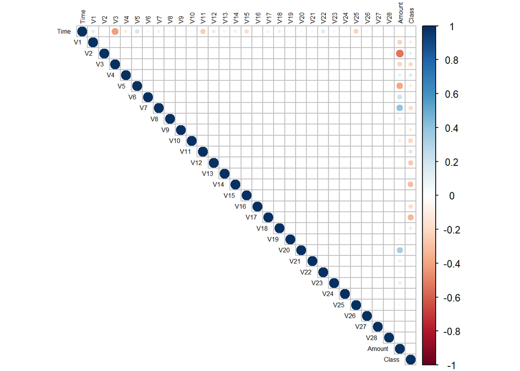

```r
correlation = cor(df, method = "pearson")
corrplot(correlation, number.cex = .9, method = "circle", type = "upper", tl.cex=0.5,tl.col = "black")
```

Here we can observe that there’s little correlation between the variables v1-v28 this is a consequence of PCA. Amount on the otherhands show significant correlation with some of t he variables.

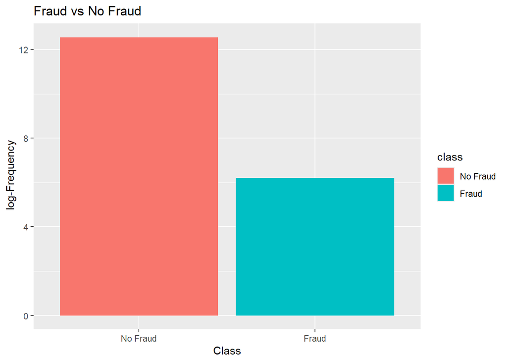

```r
table <- table(df$Class)
table <- as.data.frame(table)
colnames(table) <- c("class","frequency")
table$class <- factor(table$class,levels = c("0", "1"),labels = c("No Fraud", "Fraud"))
ggplot(table, aes(x = class, y = log(frequency), fill = class)) +
  geom_bar(stat = "identity") +
  labs(x = "Class", y = " log-Frequency", title = "Fraud vs No Fraud")
```

Here we can see that even in log scale the number of normal transaction is siginificantly higher than fradulant one, highlighting the imbalance nature of the classification. Therefore classification should be treated with care.

In this part of the project, we will examine the performance of random forest method in classification task on fraud detection using the credit card fraud data. Here we will follow directly the approach used by Gabriel Preda original found in https://www.kaggle.com/code/nschneider/gbm-vs-xgboost-vs-lightgbm. Here I reduced the number of tree he used from 100 to 5 for the sake of time. As the goal is to examine general uses of the method

First initialised the data train and test data using random sampling, splitting the train and test data into 70/30 ratio

```r
set.seed(677)
train.test.split <- sample(2
    , nrow(df)
    , replace = TRUE
    , prob = c(0.7, 0.3))
trainset = df[train.test.split == 1,]
verset = df[train.test.split == 2,]

trainset$Class <- factor(trainset$Class)
verset$Class   <- factor(verset$Class)
```

```r
n <- names(trainset)
rf.form <- as.formula(paste("Class ~", paste(n[!n %in% "Class"], collapse = " + ")))
trainset.rf <- randomForest(rf.form,trainset,ntree=5,importance=T)
```

```r
pred_class <- predict(trainset.rf, newdata = verset, type = "class")
cm <- confusionMatrix(data = pred_class, reference = verset$Class)
cm
```

```
## Confusion Matrix and Statistics
##
##           Reference
## Prediction     0     1
##          0 85474    43
##          1    13   115
##
##                Accuracy : 0.9993
##                  95% CI : (0.9992, 0.9995)
##     No Information Rate : 0.9982
##     P-Value [Acc > NIR] : < 2.2e-16
##
##                   Kappa : 0.8039
##
##  Mcnemar's Test P-Value : 0.0001065
##
##             Sensitivity : 0.9998
##             Specificity : 0.7278
##          Pos Pred Value : 0.9995
##          Neg Pred Value : 0.8984
##              Prevalence : 0.9982
##          Detection Rate : 0.9980
##    Detection Prevalence : 0.9985
##       Balanced Accuracy : 0.8638
##
##        'Positive' Class : 0
##
```

ROC curve is used to examine the true positive rate against false positive. Here ROC is used mainly to compute AUC (Area under the ROC curve) which is a commonly use metric for measuring the performance of the binary classification model.

```r
rf_prob <- predict(trainset.rf, newdata = verset, type = "prob")
roc_obj <- roc(verset$Class, rf_prob[,2])
```

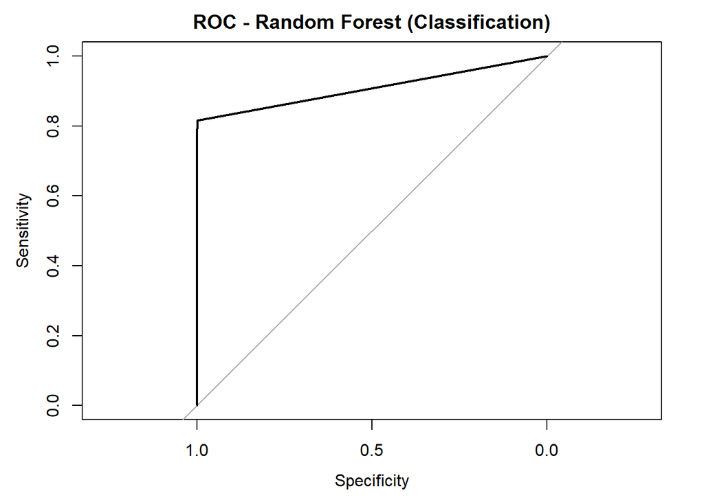

```r
plot(roc_obj, lwd = 2, main = "ROC - Random Forest (Classification)")
```

```r
auc(roc_obj)
```

```
## Area under the curve: 0.9079
```

In the original approach the method of sampling used were random sample. Given the heavily skewed property of the data (large number of non fraud compares to fraud) the resulting classifier will be heavily bias in favor of the non fraud result, Hence to compensate for this we examine methods such as smote described in https://en.wikipedia.org/wiki/Synthetic_minority_oversampling_technique. I’ll be using 100 tree for each test, to make the result less prone to biases.

First i rescale the the data as smote use KNN method for sampling which is sensitive to scale.

```r
# Scale only numeric columns
  df[, !(names(trainset) == "Class")] <- scale(df[, !(names(trainset) == "Class")])

  # Display the first few rows of the dataset to verify
  head(df)
```

```
## # A tibble: 6 × 31
##    Time     V1      V2    V3     V4       V5      V6      V7      V8     V9
##   <dbl>  <dbl>   <dbl> <dbl>  <dbl>    <dbl>   <dbl>   <dbl>   <dbl>  <dbl>
## 1 -2.00 -0.694 -0.0441 1.67   0.973 -0.245    0.347   0.194   0.0826  0.331
## 2 -2.00  0.608  0.161  0.110  0.317  0.0435  -0.0618 -0.0637  0.0713 -0.232
## 3 -2.00 -0.693 -0.812  1.17   0.268 -0.365    1.35    0.640   0.207  -1.38
## 4 -2.00 -0.493 -0.112  1.18  -0.610 -0.00747  0.936   0.192   0.316  -1.26
## 5 -2.00 -0.591  0.532  1.02   0.285 -0.295    0.0720  0.479  -0.227   0.744
## 6 -2.00 -0.217  0.582  0.753 -0.119  0.305   -0.0223  0.385   0.218  -0.518
## # ℹ 21 more variables: V10 <dbl>, V11 <dbl>, V12 <dbl>, V13 <dbl>, V14 <dbl>,
## #   V15 <dbl>, V16 <dbl>, V17 <dbl>, V18 <dbl>, V19 <dbl>, V20 <dbl>,
## #   V21 <dbl>, V22 <dbl>, V23 <dbl>, V24 <dbl>, V25 <dbl>, V26 <dbl>,
## #   V27 <dbl>, V28 <dbl>, Amount <dbl>, Class <dbl>
```

```r
set.seed(677)
train.test.split <- sample(2
    , nrow(df)
    , replace = TRUE
    , prob = c(0.7, 0.3))
trainset = df[train.test.split == 1,]
verset = df[train.test.split == 2,]

#randomForest need factor variable otherwise linear regression
trainset$Class <- factor(trainset$Class)
verset$Class   <- factor(verset$Class)
```

Here is the random sampling training

```r
n <- names(trainset)
rf.form <- as.formula(paste("Class ~", paste(n[!n %in% "Class"], collapse = " + ")))
trainset.rf <- randomForest(rf.form,trainset,ntree=100,importance=T)
```

Here is the smote”-ed” training set

```r
trainset_smote <- trainset[,!(names(trainset) == "Class")]
trainset_scaled <- SMOTE(trainset_smote, trainset$Class)
trainset_smote <- trainset_scaled$data
trainset_smote$class <- factor(trainset_smote$class)
```

training using smote sampling

```r
n<- names(trainset_smote)
rf.form_smote <- as.formula(paste("class ~", paste(n[!n %in% "class"], collapse = " + ")))
trainset.rf_smote <- randomForest(rf.form_smote,trainset_smote,ntree=100,importance=T)
```

here is the compision

```r
#prediction for no smote sampling
pred_class <- predict(trainset.rf, newdata = verset, type = "class")
cm <- confusionMatrix(data = pred_class, reference = verset$Class)
print(cm$table)
```

```
##           Reference
## Prediction     0     1
##          0 85482    36
##          1     5   122
```

```r
#prediction for smote sampling
pred_class_smote <- predict(trainset.rf_smote, newdata = verset, type = "class")
cm_smote <- confusionMatrix(data = pred_class_smote, reference = verset$Class)
print(cm_smote$table)
```

```
##           Reference
## Prediction     0     1
##          0 85474    36
##          1    13   122
```

```r
rf_prob <- predict(trainset.rf, newdata = verset, type = "prob")
roc_obj <- roc(verset$Class, rf_prob[,2])
print(paste(auc(roc_obj), "auc value for randomsampling"))
```

```
## [1] "0.925511399838276 auc value for randomsampling"
```

```r
rf_prob_smote <-predict(trainset.rf_smote, newdata=verset, type = "prob")
roc_obj_smote <- roc(verset$Class, rf_prob_smote[,2])
print(paste(auc(roc_obj_smote),"auc value for smote sampling"))
```

```
## [1] "0.94173257226319 auc value for smote sampling"
```

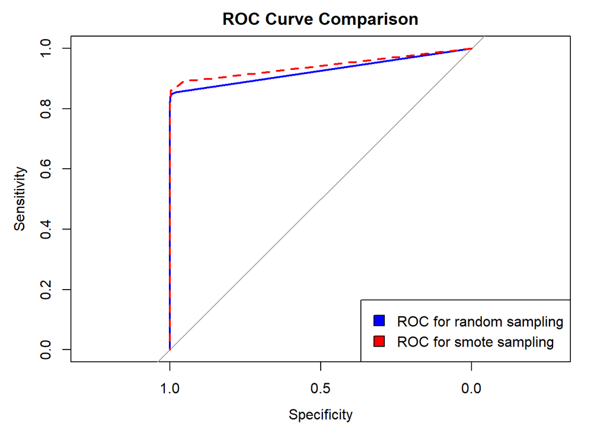

```r
plot(roc_obj, col = "blue", lwd = 2, main = "ROC Curve Comparison")
lines(roc_obj_smote, col = "red", lwd = 2, lty = 2)
legend("bottomright", legend = c("ROC for random sampling", "ROC for smote sampling"), fill = c("blue","red"))
```

Here we can see that smote-sampling slightly improves the preditability perforamance of the model accorrding to the metric AUC. However, this come at a cost of having a model that may not reflects reala scenario as the samples were mutated in such a way to compensate for the imbalance of fraudulant and normal transaction